# Final Exam

Arun Ram Sankaranarayanan

December 14, 2015

1. The five main Rs of EDA are
1. Resistance
2. Residuals
3. Re-expression
4. Revelations
5. Reiteration

There are two functions that are used to calculate the five number summary in R 1.fivenum() 2.Summary()

```r
dat = seq(1, 9, by = 2)

fivenum(dat)
```

```
## [1] 1 3 5 7 9
```

```r
summary(dat)
```

```
##    Min. 1st Qu.  Median    Mean 3rd Qu.    Max.
##       1       3       5       5       7       9
```

1. TO make the distribution more symmetric - We can easily summarice the center of the distribution that way
2. To make spread of several groups more alike - That way we can compare groups that share common spread 3.To transform the data to normality
3. Detect outliers

Generate a tailed distribution

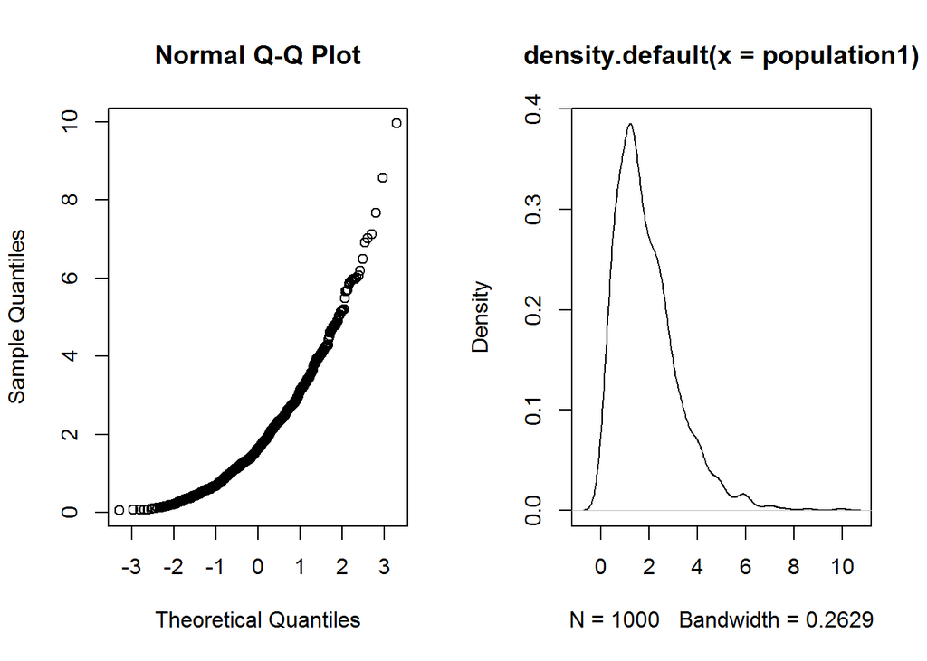

```r
population1<-rgamma(1000,shape=2)
par(mfrow=c(1,1),mfcol=c(1,2))

qqnorm(population1)
plot(density(population1))
```

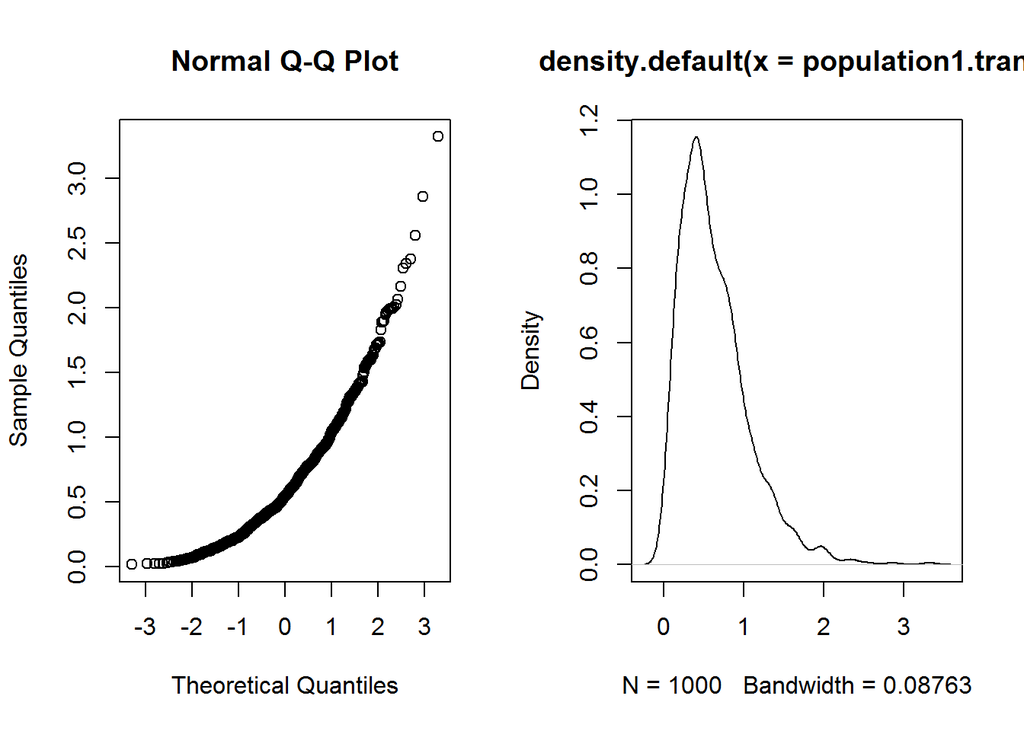

```r
population1.trans<-(population1)^1/3

qqnorm(population1.trans)
plot(density(population1.trans))
```

From the qq plot we can see the long tailness of data also with the help of gh estimators the heavy tailness can be detected

For g-H distributions

when g=0, h=0 Gaussian Data #No skewness #No Long Tails when g<0.25,h>0 slight skewness with Long Tail when gâ¼1,h>0 very skewed with Long tail

The given gh estimates are (-0.5,0.3) , (0.5,0.3), (1,0.6)

(g,h) -> (-0.5,0.3) is left skewed and has moderate tails (g,h) -> (0.5,0.3) is right skewed and has moderate tails (g,h) -> (1,0.6) is highly right skewed and has heavy tails

Given

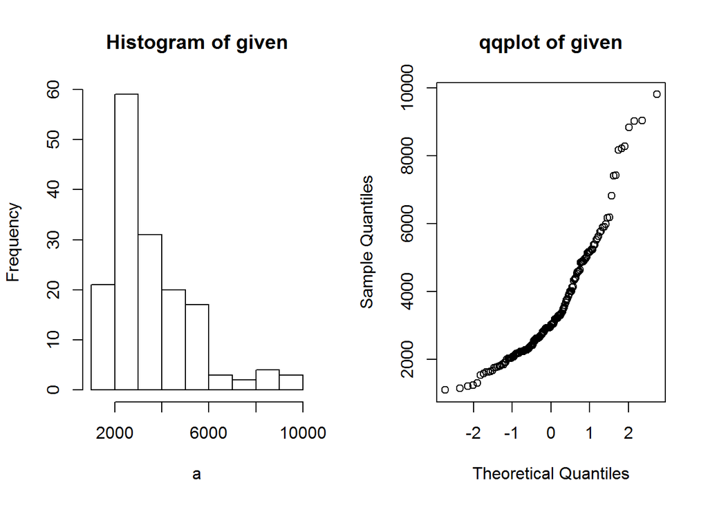

```r
a=c(1092,1137,1197,1237,1301,1523,1577,1619,1626,1644,
    1672,1748,1768,1780,1796,1816,1843,1844,1902,1919,
    1993,2025,2028,2032,2036,2072,2078,2090,2137,2162,
    2163,2180,2185,2194,2225,2230,2233,2234,2235,2265,
    2270,2274,2281,2289,2319,2322,2357,2381,2398,2421,
    2421,2443,2522,2549,2552,2581,2618,2618,2620,2624,
    2642,2647,2666,2705, 2721,2740,2804,2819,2823,2860,
    2873,2906,2913,2926,2929,2931,2931,2934,2939,2961,3020,3023,3044,3047,
    3048,3096,3174,3190,3199,3204,3222,3225,3278,3287,
    3292,3300,3339,3361,3412,3462,3503,3530,3589,3672,
    3734,3749,3783,3854,3901,3932,3995,4001,4006,4118,
    4134,4320,4346,4385,4401,4522,4565,4581,4593,4629,
    4855,4868,4878,4885,4907,4962,4975,5021,5127,5155,
    5160,5183,5229,5242,5379,5383,5513,5555,5619,5755,
    5774,5890,5899,5988,6161,6185,6818,7406,7419,8175,
    8220,8282,8827,9027,9042,9805)


#a. Construct a QQ plot

plot.new()
par(mfrow=c(1,2))


#Constructing Histogram
hist(a,main="Histogram of given")

#constructing qq plot


qqnorm(a, main="qqplot of given")
```

```r
#b use g distribution and estimate A,B,g for these data



getwd()
```

```
## [1] "C:/Users/Arun Ram/Documents/R/mid term/Exam/Final"
```

```r
source("lvalprogs.r")



#lettevalueplot
lvp<-lval(a)

n<-length(a)

print(lvp)
```

```
##   Depth  Lower  Upper     Mid Spread pseudo-s
## M  80.5 2990.5 2990.5 2990.50    0.0    0.000
## F  40.5 2267.5 4543.5 3405.50 2276.0 1687.201
## E  20.5 1956.0 5448.0 3702.00 3492.0 1517.800
## D  10.5 1658.0 6501.5 4079.75 4843.5 1578.592
## C   5.5 1412.0 8251.0 4831.50 6839.0 1835.745
## B   3.0 1197.0 9027.0 5112.00 7830.0 1817.655
## A   2.0 1137.0 9042.0 5089.50 7905.0 1634.914
## Z   1.5 1114.5 9423.5 5269.00 8309.0 1561.803
## Y   1.0 1092.0 9805.0 5448.50 8713.0 1509.720
```

```r
a1 <- 1/2^(1:9)
g1 <- abs(qnorm(a1))
a2 <- (lvp[,1]-1/3)/(n + 1/3)
g2 <- abs(qnorm(a2))

e2.g <- log((lvp[,3] - lvp[1,2])/(lvp[1,2]-lvp[,2]))/g2


plot(1:(dim(lvp)[1]-1), e2.g[-1],
     xlab="Letter value(1=F, 2=E, 3=D, ... , 8=Y)",
     ylab="g estimate")
abline(h=median(e2.g[-1]))



#g estimate

e.g <- median(e2.g[-1])


cat("Estimate of g:",e.g)
```

```
## Estimate of g: 0.6023315
```

```r
#estimate a and b


source ("rrline.r")


pol <- c(rev(qnorm(a2)),abs(qnorm(a2)))

e.Y <- (exp(e.g*pol)-1)/e.g

y<-c(rev(lvp[,2]),lvp[,3])
plot(e.Y,y)


rline<-run.rrline(e.Y,y)

abline(rline$a, rline$b)


cat("G estimate =",e.g, ",A estimate=" , rline$a, " and B estimate =" ,rline$b)
```

```
## G estimate = 0.6023315 ,A estimate= 2981.679  and B estimate = 1317.049
```

[figure not shown]

```r
#c Bootstrap estimates


library(ggplot2)
```

```r
library(GGally)
```

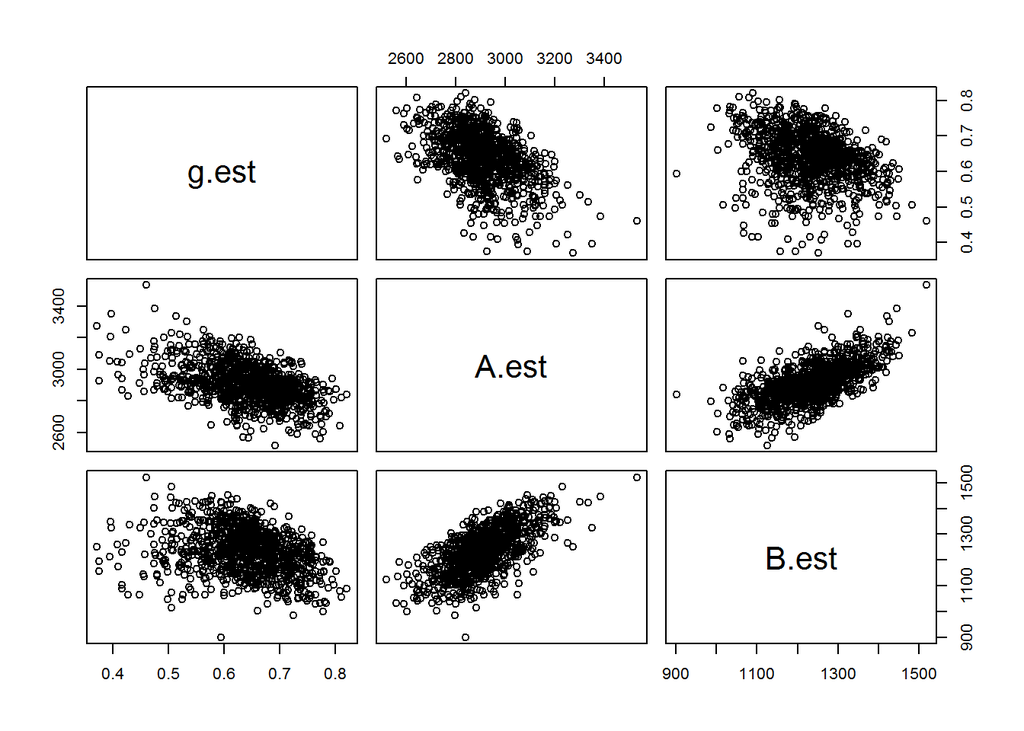

```r
g.dist.estimates<-function(sample.pop){
  source("lvalprogs.r")
  source("rrline.r")
  ll<-lval(sample.pop)
  pp1 <- 1/2^(1:nrow(ll)-1)
  gau1 <- abs(qnorm(pp1))
  pp2 <- abs((pp1-1/3)/(nrow(ll)-1 + 1/3))
  gau2 <- abs(qnorm(abs(pp2)))
  est2.g <- log((ll[,3] - ll[1,2])/(ll[1,2]-ll[,2]))/gau2

  # Estimation of g
  est.g <- median(est2.g[-1])
  p <- c(0.005, 0.01, 0.025, 0.05, 0.1, 0.25, 0.5, 0.75, 0.9, 0.95, 0.975, 0.99, 0.995)
  zp <- qnorm(p)
  est.Y <- (exp(est.g*zp)-1)/est.g
  rr <- run.rrline(est.Y,quantile(sample.pop,p))
  #Run Resistant Regression for A and B Estimates
  return (list(g=est.g,A=rr$a,B=rr$b))
}


bootstrap.g<-function(pops,sims){
  g.est <- c()
  A.est <- c()
  B.est <- c()
  for (i in 1:sims){
    boot.sample<-sample(pops,length(pops),replace = TRUE)
    r.val <- g.dist.estimates(boot.sample)
    g.est[i]<-r.val$g
    A.est[i]<-r.val$A
    B.est[i]<-r.val$B
  }
  best.g <- mean(g.est)
  g.lower <- best.g - qt(0.975,df=length(g.est)-1)*sd(g.est)
  g.upper <- best.g + qt(0.975,df=length(g.est)-1)*sd(g.est)
  best.A <- mean(A.est)
  A.lower <- best.A - qt(0.975,df=length(A.est)-1)*sd(A.est)
  A.upper <- best.A + qt(0.975,df=length(A.est)-1)*sd(A.est)
  best.B <- mean(B.est)
  B.lower <- best.B - qt(0.975,df=length(B.est)-1)*sd(B.est)
  B.upper <- best.B + qt(0.975,df=length(B.est)-1)*sd(B.est)
  cor.est <- cor (cbind(g.est,A.est,B.est))
  es.plt <- pairs(as.data.frame(cbind(g.est,A.est,B.est)))
  return(list(g=best.g,a=best.A,b=best.B,g.lower,g.upper,A.lower,A.upper,B.lower,B.upper,cor.est,es.plt))
}
a<-c(1092,1137,1197,1237,1301,1523,1577,1619,1626,1644,1672,1748,1768,1780,1796,1816,1843,1844,1902,1919,1983,1993,2025,2028,2032,2036,2072,2078,2090,2137,2162,2163,2180,2185,2194,2225,2230,2233,2234,2235,2265,2270,2274,2281,2289,2319,2322,2357,2381,2398,2421,2421,2443,2522,2549,2552,2581,2618,2618,2620,2624,2642,2647,2666,2705,2721,2740,2804,2819,2823,2860,2873,2906,2913,2926,2929,2931,2931,2934,2939,2961,3020,3023,3044,3047,3048,3096,3174,3190,3199,3204,3222,3225,3278,3287,3292,3300,3339,3361,3412,3462,3503,3530,3589,3672,3734,3749,3783,3854,3901,3932,3995,4001,4006,4118,4134,4320,4346,4385,4401,4522,4565,4581,4593,4629,4855,4868,4878,4885,4907,4962,4975,5021,5127,5155,5160,5183,5229,5242,5379,5383,5513,5555,5619,5755,5774,5890,5899,5988,6161,6185,6818,7406,7419,8175,8220,8282,8827,9027,9042,9805)
bs.val <- bootstrap.g(a,1000)
```

```r
print(paste("The g Estimate is ",bs.val[1]))
```

```
## [1] "The g Estimate is  0.640785440184216"
```

```r
print(paste(" and Confidence interval is between",bs.val[4]," and ",bs.val[5]))
```

```
## [1] " and Confidence interval is between 0.494667472879012  and  0.786903407489421"
```

```r
print(paste("The A Estimate is ",bs.val[2]))
```

```
## [1] "The A Estimate is  2911.14232974624"
```

```r
print(paste(" and Confidence interval is between",bs.val[6]," and ",bs.val[7]))
```

```
## [1] " and Confidence interval is between 2673.35085809729  and  3148.93380139518"
```

```r
print(paste("The B Estimate is ",bs.val[3]))
```

```
## [1] "The B Estimate is  1233.91371501814"
```

```r
print(paste(" and Confidence interval is between",bs.val[8]," and ",bs.val[9]))
```

```
## [1] " and Confidence interval is between 1063.50010183516  and  1404.32732820111"
```

```r
print(bs.val[10])
```

```
## [[1]]
##            g.est      A.est      B.est
## g.est  1.0000000 -0.4721578 -0.2793019
## A.est -0.4721578  1.0000000  0.6520740
## B.est -0.2793019  0.6520740  1.0000000
```

```r
print(bs.val[11])
```

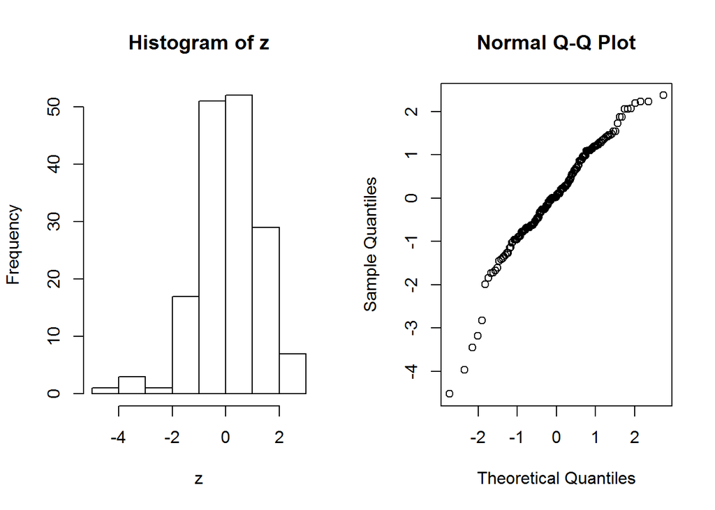

```r
g<-bs.val$g
A<-bs.val$a
B<-bs.val$b



#d


z<- 1/g*log(((a-A)*g)/B +1)
par(mfrow=c(1,2))
hist(z)
qqnorm(z)
```

```r
# The transformed data is still skewness in the left tail


#e

gof.pearson=function (x,nbins) {
  n = length(x)
  m = floor(n/nbins)
  k = n - m*nbins # This is the remainder
  xx=sort(x)
  index = rep(1:nbins,m)
  if(k >0){ d=sample(1:nbins,k,replace=FALSE);
  index=c(index,d) }
  bincount=as.numeric(table(index))
  binindicies = cumsum(bincount)
  binbreaks = rev(rev(xx[binindicies])[-1])
  binbreaks = c(-Inf,binbreaks,Inf)
  bins=cut(x,breaks=binbreaks)
  internalbreaks = rev(rev(xx[binindicies])[-1])
  p = pnorm(internalbreaks,mean(x),sd(x))
  p = c(p[1],diff(p),1-pnorm(max(internalbreaks),mean(x),sd(x)))
  exp = n*p
  df = data.frame(bin=levels(bins),bincount=bincount,prob=p,expectedcount=exp)
  chisqstat = sum((bincount - exp)^2/exp)
  pval = 1- pchisq(chisqstat,nbins-1)
  output = list(df=df,chisq=chisqstat,pval=pval)
  output = list(df=df,chisq=chisqstat,pval=pval)
}
out.p<-gof.pearson(z,2*sqrt(length(z))) #usinf Velleman rule
out.p
```

```
## $df
##                  bin bincount        prob expectedcount
## 1       (-Inf,-1.99]        6 0.040439487      6.510757
## 2      (-1.99,-1.45]        6 0.059924102      9.647780
## 3      (-1.45,-1.16]        7 0.050143709      8.073137
## 4     (-1.16,-0.952]        6 0.045092946      7.259964
## 5    (-0.952,-0.769]        6 0.045940287      7.396386
## 6    (-0.769,-0.681]        6 0.023968190      3.858879
## 7    (-0.681,-0.627]        6 0.015402015      2.479724
## 8    (-0.627,-0.503]        6 0.036911175      5.942699
## 9    (-0.503,-0.325]        6 0.055802513      8.984205
## 10   (-0.325,-0.252]        6 0.023880069      3.844691
## 11   (-0.252,-0.145]        6 0.035539294      5.721826
## 12 (-0.145,-0.00417]        6 0.047765007      7.690166
## 13 (-0.00417,0.0184]        6 0.007691519      1.238335
```

[output cut: 18 more lines]

```r
library("goftest")
```

```r
#Correlation of the QQ Data test
qqnorm(z)
qqline(z)

#Shapiro Wilk's Test
shapiro.test(z)
```

```
##
##  Shapiro-Wilk normality test
##
## data:  z
## W = 0.96109, p-value = 0.0001755
```

```r
#Anderson-Darling Test
ad.test(z,"pnorm")
```

```
##
##  Anderson-Darling test of goodness-of-fit
##  Null hypothesis: Normal distribution
##
## data:  z
## An = 1.7235, p-value = 0.1311
```

```r
#Kolmogorov Test
ks.test(z,"pnorm")
```

```
##
##  One-sample Kolmogorov-Smirnov test
##
## data:  z
## D = 0.085544, p-value = 0.1894
## alternative hypothesis: two-sided
```

```r
#Cramer-von-Mises Test
cvm.test(z,"pnorm")
```

```
##
##  Cramer-von Mises test of goodness-of-fit
##  Null hypothesis: Normal distribution
##
## data:  z
## omega2 = 0.20535, p-value = 0.2575
```

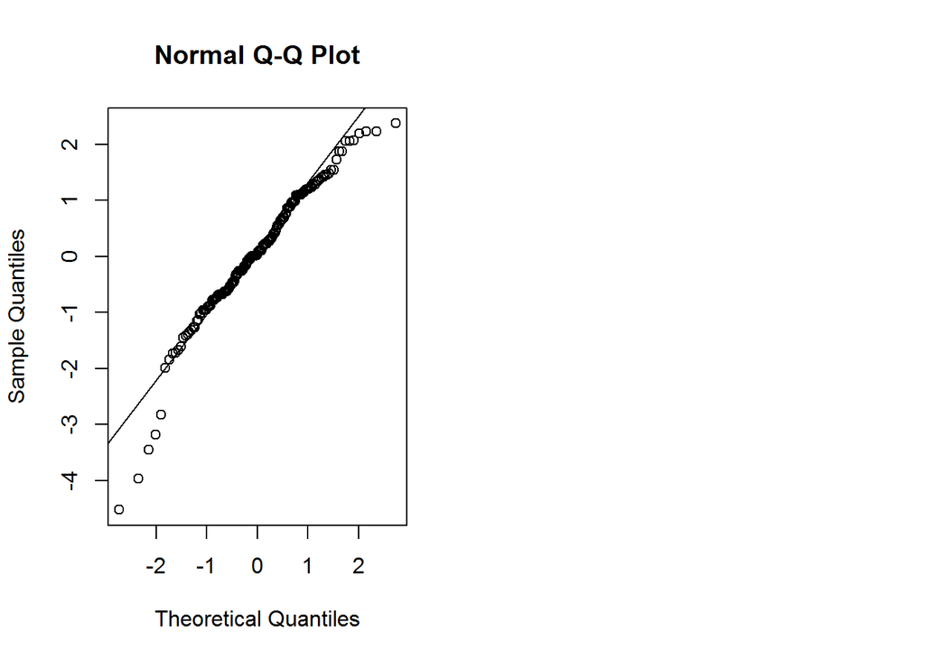

ECDF Based Test Statistics -Empirical testing has found[5] that the Anderson-Darling test is not quite as good as Shapiro Wilk test

Pearson goodness of Fit Test - A sample with a sufficiently large size is assumed - If a Pearson Goodness of fit test is conducted on a sample with a smaller size, then the Pearson Goodness of fit test will yield an inaccurate inference -The observations are always assumed to be independent of each other